# Final_write-up for BI 410L: Data Science in Ecology

Jordynn Risdal

Lily Lawrence

2025-12-10

# Native Plant-Pollinator Interactions in High Elevation Oregon Meadows

## 1. Introduction:

Invasive species are known to have a negative impact on native species and ecosystems around the world. Non-native plant invasions contribute to dwindling populations of native plant species that are ecologically and culturally important. Similarly, non-native pollinators can outcompete native species and contribute to population decline. This can further affect native plants that rely on native pollinators for efficient pollination if invasive species don’t replace the same functions. However, the specific effects invasions can have on plant-pollinator interactions can vary. A review paper by Traveset and Richardson (2006) explains that invasive pollinators can have little to no impact on highly specialized native plant-pollinator mutualisms because invasive pollinators tend to be generalists and will interact with a wider variety of plant species. Invasive plants can have more of an impact on these native mutualisms, especially if they are more attractive to native pollinators and outcompete native plants. A study by Morales and Traveset (2009) found that native or ‘alien’ species can negatively impact pollinator visitation rates and reproduction of native co-flowering focal species, which may contribute to their ability to dominate landscapes and alter plant community and structure. Invasive pollinators and plants may even interact with each other to have a greater impact on native plant-pollinator communities. For example, Barthell et al. (2001) investigated the interactions between an invasive bee, Apis mellifera, and an invasive plant, Centaurea solstitialis, and found that A. mellifera increases the reproductive success of C. solstitialis, suggesting that invasive plant-pollinator mutualisms could contribute to more successful plant invasions, further impacting native plant-pollinator interactions.

With all of these variable effects, it is important to understand native plant-pollinator interactions locally in order to better predict how invasions may impact the community in a certain place. More specific place-based studies have investigated how invasive pollinators can impact native plant-pollinator communities, primarily due to competition with native pollinators. For example, Dohzono et al. (2008) found that a Japanese native bumblebee Bombus ardens visited a native plant, Corydalis ambigua, much less frequently when the invasive Bombus terrestris visited. This resulted in lower reproduction for the plant because B. terrestris robs nectar without contributing to pollination. Most of the research on invasive pollinators centers on the very successful Apis mellifera, or European honeybee, which has been brought all over the world to live alongside agricultural fields in order to pollinate crops and make honey. But their introduction into any ecosystem can have an impact on native bees and plants. For example, when Thomson (2004) studied the interactions between a California native social bee, B. occidentalis, and A. mellifera, they found that B. occidentalis colonies located closer to A. mellifera hives had lower reproductive success, which could have a further impact on plant species that rely on this native bee. Another study by Dupont et al. (2004) focusing on the impact of A. mellifera found that these pollinators can disrupt native pollination networks by altering native bee foraging behaviours and increasing competition for nectar in flowering populations. Similarly in a meta-analysis paper, Morales and Traveset (2009) monitored visitation rate and reproductive success of native plant species located next to alien plant species. The paper proposed that the two most important properties of alien plant competition are floral abundance and the similarity of floral morphologies with native plants. The latter in particular can encourage native bees to pollinate non-natives, while specialist native plants are out-competed.

However, not all research has found a negative impact of invasive species on native plant-pollinator networks. In a study by Borchardt et al. (2025) on plant-pollinator interactions in prairie strips alongside agricultural fields in California, they found little to no impact of A. mellifera presence on native bee community composition from June to August. Similarly, Spessa (1999) studied the impact of honeybee presence on a native colletid bee Amphylaeus morosus and detected no negative impact, concluding that nectar and pollen were not limiting for A. morosus and the null hypothesis was accepted, even though there was a resource overlap between the two study species. With the variable results from different studies, it stands to reason that different species of pollinator will be limited by different factors Paini (2004).

Most of the research into how invasive species, especially pollinators like A. mellifera, impact native plant-pollinator interactions are situated close to more human-altered landscapes, such as agricultural areas. There is less research into native plant-pollinator interactions and how invasive species alter them in more remote areas. In our research, we investigate native plant-pollinator associations in high-elevation meadows, which are further from dense human populations. There may not be as much of an invasive bee impact here, especially due to the lack of commercial beekeeping. We use plant-pollinator network data from the HJ Andrews experimental forest in order to explore these interactions. This data was collected in high-elevation meadows in the HJ Andrews experimental forest. It includes pollinator observations at different plant focals and data on focal plant and pollinator taxonomy, date of observation, site and plot of observation, and much more. We primarily use the identification of plants and pollinators and the date of observations. We also use plant databases, such as Oregon Flora and Calflora in order to identify which plants in the data are native or non-native. We have a list of the most common non-native bee species present in the research site. We assume all other bee species are native.

We aim to use this data to explore 3 main questions: (1) What plants do native bees more strongly associate with in high-elevation meadows in Oregon? Are they more often native or non-native? (2) Do non-native bees compete with native bees for access to native plants in these meadows? and (3) How do the interactions between native bees and their preferred plants change over the growing season in high-elevation meadows? We first predict that native bees will more strongly associate with native plants in high-elevation meadows in Oregon. This is because native bees and plants have coexisted for longer and may have coevolved to be more specialized, especially in montane regions which have forced them to adapt to harsher conditions compared with other ecoregions. We also predict that there will be little to no significant change in native plant-pollinator relationships in the presence of non-native bees due to a low presence of non-native bees. We expect a lower presence of non-native bees because the montane study region may have environmental constraints that lead to native species easily out-competing non-native species that aren’t so well adapted and haven’t historically been introduced here like A. mellifera has in agricultural areas. Finally, we predict that native bees may shift to stronger associations with non-native plants later in the growing season due to potentially later blooming non-native species, while native species may bloom earlier.

Our findings will provide insight into how invasive plants impact interactions between native plants and bees in high elevation meadows, whether there is interspecific competition for native plant resources between native and non-native bees in this ecosystem, and how these dynamics may be amplified or dampened over phenological time. The study of these interactions in this region is important because wilder areas have been understudied compared to urban and agricultural areas and plant-pollinator networks have been shown to react to invasion differently depending on the species and location. We need to better understand these interactions to track how potential future disturbances, such as invasions, may affect the structure of these communities.

## 2. Data / Data wrangling:

We used plant-pollinator interaction data collected from high-elevation meadows in the HJ Andrews experimental forest. It includes pollinator observations at different plant focals and data on focal plant and pollinator taxonomy, date of observations, site and plot of observations, and much more. We used the date and the plant and pollinator taxonomy data to answer questions surrounding plant-pollinator interactions. We also accessed the Oregon Flora and Calflora databases in determining whether plant species were native or not. Oregon Flora is a program owned by the department of Botany and Plant Pathology at Oregon State University and it aggregates data from multiple different partners that was collected by many different parties and people. Calflora is a non-profit database that also aggregates data from a wide variety of sources collected by many different parties and people. We used Copilot to reference these databases because they didn’t have downloadable files including the native status data that we wanted to access. Once we had a list of the native species included in the HJ Andrews data, we created a new column for the native status of each plant species. We also created a new column for the native status of each pollinator species using a list of the most common non-native pollinator species given to us by our advisor.

read in HJ Andrews data

```r
raw_data<- read.csv("raw_data/spec_net_copy.csv")
```

Get rid of unwanted columns, keep GenusSpecies, PlantGenusSpecies & Date.

```r
library(tidyverse)
library(dplyr)
##only keeping date, pollinator species and plant species columns
kept_columns<- raw_data %>%
  select(Date, GenusSpecies, PlantGenusSpecies) %>%
  rename(PollinatorGenusSpecies= GenusSpecies) %>% #rename GenusSpecies to PollinatorGenusSpecies to more easily differentiate
  dplyr::filter(PollinatorGenusSpecies!="") %>%
  dplyr::filter(PlantGenusSpecies!="")           #get rid of empty rows
```

transform date to month number

```r
class(kept_columns) #test class= data frame
```

```
## [1] "data.frame"
```

```r
#replacing the values in the Date column with only the first number of each, which is the month
kept_columns$Date <- sub("^(\\d{1,2})/.*", "\\1", kept_columns$Date)

#rename Date to Month
kept_columns <- kept_columns%>%
  rename(Month = Date)

##test to make sure months are now just months, should be single numbers and not a full date
table(kept_columns$Month)
```

```
##
##     6     7     8     9
##  5028 22023  4962   103
```

```r
#change month values from characters to numerics
kept_columns$Month<- as.numeric(kept_columns$Month)

#test that months are numeric
class(kept_columns$Month)
```

```
## [1] "numeric"
```

use regular expressions (regex) to filter out spp/sp (unknown) species

```r
#test to see what pollinator species name are present
unique(kept_columns$PollinatorGenusSpecies)
```

```
##   [1] "Bombus mixtus"                    "Bombus melanopygus"
##   [3] "Bombus vosnesenskii"              "Dufourea calochorti"
##   [5] "Hylaeus wootoni"                  "Lasioglossum sp."
##   [7] "Andrena pertristis"               "Andrena vicinoides"
##   [9] "Bombus vancouverensis"            "Sphecodes sp."
##  [11] "Bombus griseocollis"              "Halictus rubicundus"
##  [13] "Colletes simulans"                "Apis mellifera"
##  [15] "Bombus californicus"              "Nomada sp."
##  [17] "Osmia sp."                        "Chelostoma phaceliae"
##  [19] "Halictus tripartitus"             "Hoplitis fulgida"
##  [21] "Melissodes sp."                   "Andrena scutellinitens"
##  [23] "Dianthidium ulkei"                "Hylaeus nunnenmacheri"
##  [25] "Osmia coloradensis"               "Panurginus sp."
##  [27] "Bombus appositus"                 "Bombus insularis"
##  [29] "Megachile perihirta"              "Bombus nevadensis"
```

[output cut: 93 more lines]

```r
#found a lot of unknown species that we can't use because we can't determine whether they are native or not for our analysis, so we will use regular expressions to filter them out

##create regex to use for filtering
#looks for pattern ending in any variation of spp/sp with any number of "."; got from the class demo
sp_ending_regex <- "(^\\s*[A-Za-z]+\\s+)[sS][pP]{1,2}\\.?\\s*$"
#looks for pattern ending in "sp."+"any numeric" with optional space or . in between; asked copilot
sp_number_regex <- "sp\\.?\\s?[0-9]+$"
#looks for pattern that is only genus; got from class demo
genus_only_regex <-   "^\\s*([A-Za-z]+)\\s*$"

#filter rows that are not (!) in the reg expressions above (had to make 2 for 2 different formats)
no_unknown<- kept_columns %>%
  dplyr::filter(!(PollinatorGenusSpecies = grepl(sp_ending_regex,PollinatorGenusSpecies))) %>%
  dplyr::filter(!(PollinatorGenusSpecies = grepl(sp_number_regex,PollinatorGenusSpecies))) %>%
  dplyr::filter(!(PollinatorGenusSpecies = grepl(genus_only_regex,PollinatorGenusSpecies)))
```

fix plant species with no space

```r
#test to see what plant species name are present
unique(no_unknown$PlantGenusSpecies)
```

```
##   [1] "Delphinium menziesii"       "Vicia americana"
##   [3] "Viola orbiculata"           "Lathyrus nevadensis"
##   [5] "Potentilla gracilis"        "Polygonum phytolaccifolium"
##   [7] "Ligusticum grayi"           "Orthocarpus imbricatus"
##   [9] "Aquilegia formosa"          "Achillea millefolium"
##  [11] "Cirsium callilepis"         "Eriogonum compositum"
##  [13] "Symphoricarpos mollis"      "Erigeron foliosus"
##  [15] "Senecio triangularis"       "Lupinus laxiflorus"
##  [17] "Fragaria virginiana"        "Rudbeckia occidentalis"
##  [19] "Aster ledophyllus"          "Solidago canadensis"
##  [21] "Penstemon procerus"         "Potentilla glandulosa"
##  [23] "Mimulus nanus"              "Mimulus guttatus"
##  [25] "Rumex acetosella"           "Montia parvifolia"
##  [27] "Mimulus tilingii"           "Phacelia hastata"
##  [29] "Calochortus subalpinus"     "Eriophyllum lanatum"
```

[output cut: 47 more lines]

```r
#didn't find any unknown plant species, but 1 plant species is listed with no space as Liliumcolumbianum

#replace the incorrect species format with the right format using a regex and the exact correct wording
no_unknown$PlantGenusSpecies<- gsub("^Liliumcolumbianum$", "Lilium columbianum", no_unknown$PlantGenusSpecies)

#check to see that it's been replaced
unique(no_unknown$PlantGenusSpecies)
```

```
##   [1] "Delphinium menziesii"       "Vicia americana"
##   [3] "Viola orbiculata"           "Lathyrus nevadensis"
##   [5] "Potentilla gracilis"        "Polygonum phytolaccifolium"
##   [7] "Ligusticum grayi"           "Orthocarpus imbricatus"
##   [9] "Aquilegia formosa"          "Achillea millefolium"
##  [11] "Cirsium callilepis"         "Eriogonum compositum"
##  [13] "Symphoricarpos mollis"      "Erigeron foliosus"
##  [15] "Senecio triangularis"       "Lupinus laxiflorus"
##  [17] "Fragaria virginiana"        "Rudbeckia occidentalis"
##  [19] "Aster ledophyllus"          "Solidago canadensis"
##  [21] "Penstemon procerus"         "Potentilla glandulosa"
##  [23] "Mimulus nanus"              "Mimulus guttatus"
##  [25] "Rumex acetosella"           "Montia parvifolia"
##  [27] "Mimulus tilingii"           "Phacelia hastata"
##  [29] "Calochortus subalpinus"     "Eriophyllum lanatum"
```

[output cut: 47 more lines]

make column for native plants- 1 for native (TRUE), 0 for non-native (FALSE)

```r
##Use unique to pull out unique species in PlantGenusSpecies
plant_species<- unique(no_unknown$PlantGenusSpecies)
##copied and pasted this vector and asked copilot to reference supplemental databases Oregon Flora and Calflora to see which plant species listed in the vector are native and which are non-native
##according to Oregon Flora and Calflora, two species has both a native version and introduced version from Eurasia: Achillea millefolium and Prunella vulgaris- decided to include them as natives because the species still counts as native
##there were also four species that are non-native: Rumex acetosella, Hypericum perforatum, Taraxacum officinale, Vicia sativa

#vector representing native species without the non-native species or those that could go either way
native_plants<- c(
  "Delphinium menziesii","Vicia americana","Viola orbiculata","Lathyrus nevadensis",
  "Potentilla gracilis","Polygonum phytolaccifolium","Ligusticum grayi","Orthocarpus imbricatus",
  "Aquilegia formosa","Cirsium callilepis","Eriogonum compositum","Symphoricarpos mollis",
  "Erigeron foliosus","Senecio triangularis","Lupinus laxiflorus","Fragaria virginiana",
  "Rudbeckia occidentalis","Aster ledophyllus","Solidago canadensis","Penstemon procerus",
  "Potentilla glandulosa","Mimulus nanus","Mimulus guttatus","Montia parvifolia",
  "Mimulus tilingii","Phacelia hastata","Calochortus subalpinus","Eriophyllum lanatum",
  "Amelanchier alnifolia","Penstemon cardwellii","Arenaria macrophylla","Sedum oreganum",
  "Silene douglasii","Arctostaphylos nevadensis","Sorbus sitchensis","Rosa gymnocarpa",
  "Castilleja hispida","Zigadenus venenosus","Phlox gracilis","Collinsia parviflora",
  "Epilobium anagallidifolium","Angelica arguta","Gilia capitata","Eriogonum umbellatum",
  "Acmispon nevadensis","Agoseris heterophylla","Eriogonum nudum","Lomatium martindalei",
  "Erysimum asperum","Arenaria capillaris","Ranunculus uncinatus","Clarkia amoena",
  "Lomatium triternatum","Rainiera stricta","Stachys cooleyae","Holodiscus dumosus",
  "Polemonium carneum","Dichelostemma congestum","Gayophytum humile","Stellaria crispa",
  "Rubus parviflorus","Heracleum lanatum","Tiarella trifoliata","Smilacina racemosa",
  "Anaphalis margaritacea","Chamerion angustifolium","Dodecatheon jeffreyi","Mertensia bella",
  "Boykinia major","Perideridia gairdneri","Microseris nutans","Campanula scouleri",
  "Castilleja miniata","Apocynum androsaemifolium","Senecio integerrimus","Erigeron aliceae",
  "Vancouveria hexandra","Mitella pentandra","Mimulus moschatus","Montia sibirica",
  "Sedum oregonense","Hypericum anagalloides","Mertensia paniculata","Platanthera sparsiflora",
  "Cerastium arvense","Erythronium grandiflorum","Hydrophyllum occidentale","Stachys chamissonis",
  "Lilium columbianum","Drymocallis glandulosa","Epilobium ciliatum","Lithophragma parviflorum",
  "Erysimum capitatum","Symphoricarpos albus","Saxifraga occidentalis","Hieracium cynoglossoides",
  "Holodiscus discolor","Claytonia lanceolata","Phacelia heterophila","Stachys rigida",
  "Xerophyllum tenax","Agoseris aurantiaca","Collinsia grandiflora","Solidago elongata",
  "Solidago lepida","Navarretia divaricata","Symphyotrichum foliaceum","Gayophytum diffusum",
  "Maianthemum stellatum","Barbarea orthoceras","Mimulus rubellus","Lewisia triphylla",
  "Viola glabella","Pedicularis bracteosa","Acmispon americanus","Lupinus latiflorus",
  "Valeriana sitchensis","Epilobium oregonense", "Achillea millefolium", "Prunella vulgaris"
)

#check length to make sure copilot gave back the right number of species excluding the non-natives, should be 118
length(native_plants)
```

```
## [1] 120
```

```r
##add NativePlant column to dataframe- if listed plant species in PlantGenusSpecies is in the native_plants vector, NativePlant will have TRUE, otherwise it will have FALSE
w_native_plants<- no_unknown %>%
  mutate(
    NativePlant = ifelse (PlantGenusSpecies %in% native_plants, yes=1, no=0)
  )

#check that values came out right
unique(w_native_plants$NativePlant)
```

```
## [1] 1 0
```

add native pollinator column- 1 for native, 0 for non-native

```r
##used common non-native list from Lauren
non_native_bees<- c("Apis mellifera", "Megachile rotundata", "Anthidium manicatum", "Osmia cornifrons")

w_native_pollinators<- w_native_plants %>%
  mutate(
    NativePollinator = ifelse (PollinatorGenusSpecies %in% non_native_bees, yes=0, no=1)
  )

#check that values came out right
unique(w_native_pollinators$NativePollinator)
```

```
## [1] 1 0
```

check final dataframe and export file to repository

```r
str(w_native_pollinators)
```

```
## 'data.frame':    29553 obs. of  5 variables:
##  $ Month                 : num  7 7 7 7 7 7 7 7 7 7 ...
##  $ PollinatorGenusSpecies: chr  "Bombus mixtus" "Bombus mixtus" "Bombus mixtus" "Bombus mixtus" ...
##  $ PlantGenusSpecies     : chr  "Delphinium menziesii" "Delphinium menziesii" "Delphinium menziesii" "Delphinium menziesii" ...
##  $ NativePlant           : num  1 1 1 1 1 1 1 1 1 1 ...
##  $ NativePollinator      : num  1 1 1 1 1 1 1 1 1 1 ...
```

```r
#reorder columns
re_ordered<- w_native_pollinators %>%
  select(Month, PollinatorGenusSpecies, NativePollinator, PlantGenusSpecies, NativePlant)

head(re_ordered)
```

```
##   Month PollinatorGenusSpecies NativePollinator    PlantGenusSpecies
## 1     7          Bombus mixtus                1 Delphinium menziesii
## 2     7          Bombus mixtus                1 Delphinium menziesii
## 3     7          Bombus mixtus                1 Delphinium menziesii
## 4     7          Bombus mixtus                1 Delphinium menziesii
## 5     7          Bombus mixtus                1 Delphinium menziesii
## 6     7          Bombus mixtus                1 Delphinium menziesii
##   NativePlant
## 1           1
## 2           1
## 3           1
## 4           1
## 5           1
## 6           1
```

```r
#export to folder in repository called clean_data (this folder needs to be created locally)
write.csv(re_ordered, "clean_data/HJ_data.csv", row.names = TRUE)
```

## 3. Analyses and Visualizations

We ran four major analyses to answer our three main questions. The first two analyses help us answer question 1: What plants do native bees more strongly associate with in high-elevation meadows in Oregon? Are they more often native or non-native? First, we created two interaction networks to visualize the strength of interactions between plant and pollinator species. We grouped the species by native status to see if there was a visual difference in whether native pollinators interacted more with native or non-native plants. Second, we ran a hypothesis test to see if the difference in native pollinator interactions with native vs. non-native plants was significant. The third analysis helps us answer question 2: Do non-native bees compete with native bees for access to native plants in high elevation meadows? To address this, we grouped observations by plant species and plotted native pollinator observations by non-native pollinator observations to see if non-native presence pollinator correlated with a decrease in native presence. Our fourth analysis helps us answer question 3: How do the interactions between native bees and their preferred plants change over the growing season in high-elevation meadows? To see if there was a clear preference for native pollinators and if it changed over time, we grouped observations by the native status of the plant visited and plotted the proportion of total visits each month that occurred to native plants vs. non-native plants.

### A. Answering research question 1: What plants do native bees more strongly associate with in high-elevation meadows in Oregon? Are they more often native or non-native?

**Analysis of interaction data: group species by type (plant vs. pollinator) and native status; create 2 sankey interaction networks- one broken down by species and one that just shows the groups**

read in cleaned data

```r
clean_data<- read.csv("clean_data/HJ_data.csv")
```

keep only plant and pollinator species columns

```r
library(tidyr)
library(dplyr)

##select only relevant columns- PollinatorGenusSpecies and PlantGenusSpecies
interactions<- clean_data %>%
  select(PollinatorGenusSpecies, PlantGenusSpecies)
```

convert data frame into biadjacency matrix

```r
## table the dataframe to sum up interactions between each plant and pollinator species and unclass it as a table so it is recognized as a matrix
interactions_adj<- unclass(table(interactions))

#check class- should be matrix
class(interactions_adj)
```

```
## [1] "matrix" "array"
```

convert matrix to igraph object

```r
library(igraph)
## convert regular adjacency matrix to igraph bipartite adjacency matrix
# use weight=TRUE to preserve the strength of interactions (when there is more than 1 observation of a bee species interacting with a given plant species)
interactions_igraph <- graph_from_biadjacency_matrix(interactions_adj, weight=TRUE)

# check class- should be igraph
class(interactions_igraph)
```

```
## [1] "igraph"
```

convert igraph to a network 3d object

```r
library(networkD3)
```

```r
###make meaningful groups- Native vs. non-native pollinators and plants
## create a vector of all the node names in the igraph object
node_names <- V(interactions_igraph)$name

## combine species names from both plant and pollinator columns to have one dataframe of all species names and native status
#create separate dataframe of just pollinator species and native status
pol_sp<- data.frame(
  species= clean_data$PollinatorGenusSpecies,
  native= clean_data$NativePollinator,
  type= "Pollinator"
)

#create separate dataframe of just plant pollinator species and native status
plant_sp<- data.frame(
  species= clean_data$PlantGenusSpecies,
  native= clean_data$NativePlant,
  type= "Plant"
)

#combine into one dataframe of all species and native status
combined_species<- rbind(pol_sp,plant_sp)

#match combined_species to node_names so each species name is only listed once
match_to_og_df <- combined_species[match(node_names, combined_species$species), ]

##make groups based on a species type and native status
groups <- ifelse(match_to_og_df$native == 1 & match_to_og_df$type=="Pollinator",
                 "Native Pollinator",
          ifelse(match_to_og_df$native == 0 & match_to_og_df$type=="Pollinator",
                 "Non-native Pollinator",
          ifelse(match_to_og_df$native == 1 & match_to_og_df$type=="Plant",
                 "Native Plant", "Non-native Plant")))

### convert igraph to a network 3d object, using the modules as node values
interactions_net3d <- igraph_to_networkD3(interactions_igraph, group=groups,
                                       what = "both")

## check that it has two list items to use for network visualization- links and nodes
str(interactions_net3d)
```

```
## List of 2
##  $ links:'data.frame':   1053 obs. of  3 variables:
##   ..$ source: num [1:1053] 16 167 61 78 40 71 93 92 135 132 ...
##   ..$ target: num [1:1053] 174 174 174 174 174 174 174 174 174 174 ...
##   ..$ value : num [1:1053] 62 2 1 2 2 1 1 4 1 1 ...
##  $ nodes:'data.frame':   298 obs. of  2 variables:
##   ..$ name : chr [1:298] "Agapostemon virescens" "Andrena birtwelli" "Andrena buckelli" "Andrena columbiana" ...
##   ..$ group: chr [1:298] "Native Pollinator" "Native Pollinator" "Native Pollinator" "Native Pollinator" ...
```

make network visualization- we chose the Sankey plot

```r
all_species_network<- sankeyNetwork(Links = interactions_net3d$links,
             Nodes = interactions_net3d$nodes,
            Source = "source", Target = "target",
            Value = "value",  NodeID = "name",
            NodeGroup= "group", fontSize=15,
            nodePadding = 0, height = 1400, width=450)
```

insert visual

```r
all_species_network
```

[interactive chart not shown]

Figure 1. Interaction network of all pollinator and plant species present in the HJ Andrews dataset, grouped by native status. Pollinators are on the left and plants are on the right. Native species are darker blue and non-native species are lighter blue. There are only a few non-native pollinator species that make up about the same amount of interactions as a much higher number of native pollinator species. There are a lot more species of native plants that make up the large majority of plant interactions compared to non-native plants.

We also created a simplified network that groups species by whether they are native or not to more easily view the groups.

create network of just native vs non-native plant-pollinator interactions

```r
#select native and non-native plant and pollinator columns in order to group their interactions
int<- clean_data %>%
  select(NativePollinator, NativePlant)
```

convert data frame into adjacency matrix

```r
## table the dataframe to sum up interactions between native and non-native plant and pollinator species and unclass it as a table so it is recognized as a matrix
int_table<- table(int)

# unclass it as a table so it is recognized as a matrix
# the first variable in the table becomes rows and second becomes columns
int_adj<- unclass(int_table)

##reorder columns and rows so group orders match other interaction network later
reordered_int_adj <- int_adj[c(2, 1), c(2,1)]

## check Int_adj and reordered_int_adj to make sure values still match and see which columns becomes which side of the adjacency matrix- found that the columns represents pollinators and the rows represent plants
int_adj
```

```
##                 NativePlant
## NativePollinator   0     1
##                0 323 13256
##                1 884 15090
```

```r
reordered_int_adj
```

```
##                 NativePlant
## NativePollinator     1   0
##                1 15090 884
##                0 13256 323
```

```r
## rename column and row names so they more accurately describe what they are showing
colnames(reordered_int_adj) <- c("Native Plants", "Non-native Plants")
rownames(reordered_int_adj) <- c("Native Pollinators", "Non-native Pollinators")

#check that the new column and row names match the label
reordered_int_adj
```

```
##                         NativePlant
## NativePollinator         Native Plants Non-native Plants
##   Native Pollinators             15090               884
##   Non-native Pollinators         13256               323
```

convert to igraph object

```r
#preserve weight (strength of interactions)
int_igraph <- graph_from_biadjacency_matrix(reordered_int_adj, weight=TRUE)
```

convert to network 3d object

```r
### convert igraph to a network 3d object, not necessary to group because there are only 4 categories and we can easily see them all
int_net3d <- igraph_to_networkD3(int_igraph,
                                       what = "both")
```

create network visualization

```r
##uses int_net3d links and nodes, grouping by native and non-native plants and pollinators
native_network<- sankeyNetwork(Links = int_net3d$links,
             Nodes = int_net3d$nodes,
            Source = "source", Target = "target",
            Value = "value",  NodeID = "name",
            fontSize= 14,
            nodePadding = 0, height = 500, width=250)
```

insert visual

```r
native_network
```

[interactive chart not shown]

Figure 2. Simplified interaction network of grouped pollinator and plant species by native status. Pollinators are on the left and plants are on the right. Native species are darker blue and non-native species are lighter blue. There are a fairly even number of interactions for native vs. non-native pollinators, but there is a much smaller number of interactions with non-native plants compared to native plants.

**AB test: test for a significant difference in native pollinator observations between native vs. non-native plants**

Null hypothesis: there is no difference in native bee abundance between between native and non-native plants.

Alternative hypothesis: there is a significant difference in native bee abundance at native plants versus non-native plants.

Test statistic: the difference between the average native bee observations per species between native plant species and non-native plant species.

read in data and library

```r
library(tidyverse)

clean_data<- read.csv("clean_data/HJ_data.csv")
```

filter out non-native pollinators because we are only testing native pollinators

```r
#only keep columns relevant to this test-
native_bees<- clean_data %>%
  filter(NativePollinator==1) %>%
  select(PollinatorGenusSpecies, PlantGenusSpecies, NativePlant)
#now all pollinators included are native so we don't need the NativePollinator column
```

figure out how to calculate observed stat

```r
## number of bee observations per plant species
# will use this dataframe for shuffling labels
observations_by_plant<- native_bees %>%
  group_by(PlantGenusSpecies, NativePlant) %>%
  summarize(abundance= n(), .groups="drop")

## find average number of interactions per species based on group (native vs. non-native)
av_interactions<- observations_by_plant %>%
  group_by(NativePlant) %>%
  summarize(mean_interactions= mean(abundance), .groups="drop")

#find difference between them
# average number of interactions for a native species - average number of interactions for a non-native species
observed_stat <- abs(av_interactions$mean_interactions[av_interactions$NativePlant=="1"] - av_interactions$mean_interactions[av_interactions$NativePlant=="0"])

observed_stat ## 88.63158
```

```
## [1] 88.63158
```

create function to calculate observed stat using above calculations

```r
### this function calculates the observed statistic by first finding the average of observations per species for both native and non-native groups of plant species
calc_statistic<- function(df){
  #first find the average abundance for species based on group (native or non-native plants)
  df2<- df %>%
    group_by(NativePlant) %>%
    summarize(mean=mean(abundance), .groups="drop")
  #next calculate observed statistic= the difference between average abundances of each group
  obs_stat <- abs(df2$mean[df2$NativePlant=="1"]- df2$mean[df2$NativePlant=="0"])
  return(obs_stat)
  }


## test it works- should match observed statistic above of 88.63158; it does
calc_statistic(observations_by_plant)
```

```
## [1] 88.63158
```

figure out shuffling and running one test

```r
## for reproducibility
set.seed(123)

##shuffle label column from observations_by_plant to shuffle whether a given species is native or not
by_species_shuffle <-  sample(observations_by_plant$NativePlant,
                         nrow(observations_by_plant), replace=FALSE)

## create data frame to use for test without altering og
by_species_test<- observations_by_plant

#create new column with shuffled labels
by_species_test$NativePlantShuffled<- by_species_shuffle

#check that the column was added
head(by_species_test)
```

```
## # A tibble: 6 × 4
##   PlantGenusSpecies     NativePlant abundance NativePlantShuffled
##   <chr>                       <int>     <int>               <int>
## 1 Achillea millefolium            1        78                   1
## 2 Acmispon americanus             1         1                   1
## 3 Acmispon nevadensis             1        70                   1
## 4 Agoseris aurantiaca             1        16                   1
## 5 Agoseris heterophylla           1        75                   1
## 6 Amelanchier alnifolia           1         8                   1
```

```r
### new function for calculating test statistic with shuffled column instead of the original NativePlant column
### this function calculates the test statistic. It functions the same way as the calc_stat function except it uses the re-shuffled NativePlantShuffled labels instead of the original NativePlant labels that the first function used to calculate the observed statistic.
calc_stat_shuffled<- function(df){
  #first find the average abundance for species based on group with shuffled labels (native or non-native plants)
  df2<- df %>%
    group_by(NativePlantShuffled) %>%
    summarize(mean=mean(abundance), .groups="drop")
  #next calculate test statistic= the difference between averages observations per group
  stat <- abs(df2$mean[df2$NativePlantShuffled=="1"]- df2$mean[df2$NativePlantShuffled=="0"])
  return(stat)
  }

#test with by_species_test after it's been shuffled once, run whole cell a few times to ensure this gives different numbers: it does
calc_stat_shuffled(by_species_test)
```

```
## [1] 118.386
```

create function for shuffling labels and calculating test statistic from that using above manipulation and the calc_stat_shuffled function

```r
## for reproducibility
set.seed(123)

### this function creates a vector of shuffled labels from the NativePlant column from a given dataframe and adds that vector to a new column in the dataframe. It then calculates a test statistic given the newly re-shuffled lables in the dataframe using the calc-stat-shuffled function defined above.
run_one_test<- function(df){
  #first create a vector of shuffled labels (native or non-native plant) from the NativePlant column, without replacing values after they were sampled and making it the same length as the original NativePlant column so the same number of native and non-native labels are present
  shuffled_labels<- sample(df$NativePlant,
                           nrow(df), replace=FALSE)
  # next add the shuffled vector back to the dataframe
  df$NativePlantShuffled<- shuffled_labels
  # finally calculate the new test statistic from the shuffled labels using the calc_stat_shuffled function
  test_stat<- calc_stat_shuffled(df)
  return(test_stat)
}

## test function- run a couple times to ensure we get different results: we do
run_one_test(observations_by_plant)
```

```
## [1] 118.386
```

create and run for loop to shuffle and calculate test statistic 1000 times

```r
## set up empty vector to fill with test statistic values
test_stats<- vector(mode="numeric", length=0)

### this for loop runs 1000 permutation tests using the run_one_test function defined above and adds each value to an originally empty vector of test statistics
for (i in 1:1000){
  # first run a permuation test with the run_one_test function to get a test statistic back
  one_test<- run_one_test(observations_by_plant)
  # next add that new test statistic to the test_stats vector
  test_stats<- append(test_stats, one_test)
}

## look at vector to see if it filled- it is
test_stats[1:10]
```

```
##  [1]  94.57895 331.87719  41.01316 137.53509 121.49123  93.02632  54.46930
##  [8]  87.59211  73.10088 187.22368
```

```r
## test it contains numeric values- it does
class(test_stats)
```

```
## [1] "numeric"
```

find p-value

```r
## calculate p-value
# how probable that test stats are equal to observed or farther in direction of alt hypothesis
p_val <- mean(abs(test_stats) >= abs(observed_stat))
p_val
```

```
## [1] 0.584
```

```r
## gives 0.584= not significant
```

plot histogram of test statistics and observed statistic to visualize if there is a difference

```r
## turn test_stats vector into a dataframe to plot
test_stats_df<- as.data.frame(test_stats)

##plot histogram- results from for loop AND observed test statistic
test_hist<- ggplot(test_stats_df) +
  geom_histogram(aes(x=test_stats)) +
  labs(x="Test Statistic Value", y="Number of Cases", title="Test Statistic Distribution") +
  geom_point(aes(x=observed_stat, y=0),color="red")
```

insert histogram

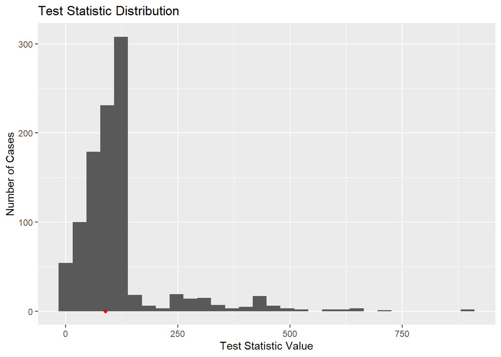

```r
test_hist
```

Figure 3. Distribution of test statistics after running AB simulation 1000 times. Observed statistic is included as a red dot for comparison. Results are not significant with a p-value of 0.584. We fail to reject the null hypothesis that there is no difference in plant preference for native pollinators.

### B. Answering research question 2: Do non-native bees compete with native bees for access to native plants in high elevation meadows?

**Analysis of pollinator competition: group by plant species; graph native bee observations by non-native bee observations**

```r
#loading in cleaned data file

clean_data <- read.csv("clean_data/HJ_data.csv")

head(clean_data)
```

```
##   X Month PollinatorGenusSpecies NativePollinator    PlantGenusSpecies
## 1 1     7          Bombus mixtus                1 Delphinium menziesii
## 2 2     7          Bombus mixtus                1 Delphinium menziesii
## 3 3     7          Bombus mixtus                1 Delphinium menziesii
## 4 4     7          Bombus mixtus                1 Delphinium menziesii
## 5 5     7          Bombus mixtus                1 Delphinium menziesii
## 6 6     7          Bombus mixtus                1 Delphinium menziesii
##   NativePlant
## 1           1
## 2           1
## 3           1
## 4           1
## 5           1
## 6           1
```

```r
#Check the count of observations for native vs non-native pollinators
clean_data %>%
  group_by(NativePollinator) %>%
  summarise(count = n())
```

```
## # A tibble: 2 × 2
##   NativePollinator count
##              <int> <int>
## 1                0 13579
## 2                1 15974
```

```r
#13579 non native bee individuals
#15974 native bee individuals

clean_data %>%
  group_by(NativePlant) %>%
  summarise(count = n())
```

```
## # A tibble: 2 × 2
##   NativePlant count
##         <int> <int>
## 1           0  1207
## 2           1 28346
```

```r
#1207 non native plants
#28346 native plants
```

```r
#creating a summary of the plant, whether non native bees were observed, and the abundance of native bee records

plants <- clean_data %>%
  group_by(PlantGenusSpecies, NativePlant) %>%
  summarise(non_nativebee_count = sum(NativePollinator == 0),
            nativebee_count = sum(NativePollinator ==1))
plants
```

```
## # A tibble: 124 × 4
## # Groups:   PlantGenusSpecies [124]
##    PlantGenusSpecies         NativePlant non_nativebee_count nativebee_count
##    <chr>                           <int>               <int>           <int>
##  1 Achillea millefolium                1                  62              78
##  2 Acmispon americanus                 1                   0               1
##  3 Acmispon nevadensis                 1                   1              70
##  4 Agoseris aurantiaca                 1                  29              16
##  5 Agoseris heterophylla               1                  63              75
##  6 Amelanchier alnifolia               1                   5               8
##  7 Anaphalis margaritacea              1                  24              20
##  8 Angelica arguta                     1                 381              80
##  9 Apocynum androsaemifolium           1                  15              89
## 10 Aquilegia formosa                   1                   0              73
## # ℹ 114 more rows
```

```r
table(plants$non_nativebee_count)
```

```
##
##    0    1    2    3    4    5    6    8    9   10   13   15   16   19   21   23
##   51   11    6    1    3    6    1    2    1    2    2    2    1    1    1    1
##   24   29   38   41   49   62   63   68   79   95  103  108  134  137  140  147
##    1    2    1    1    1    1    1    1    1    1    1    1    1    1    1    1
##  161  178  189  197  203  218  268  292  338  375  381  458  516 2259 5946
##    1    1    1    1    1    1    1    1    1    1    1    1    1    1    1
```

```r
#time to see if there is a difference in the counts of native bees due to the presence of non-native bees
```

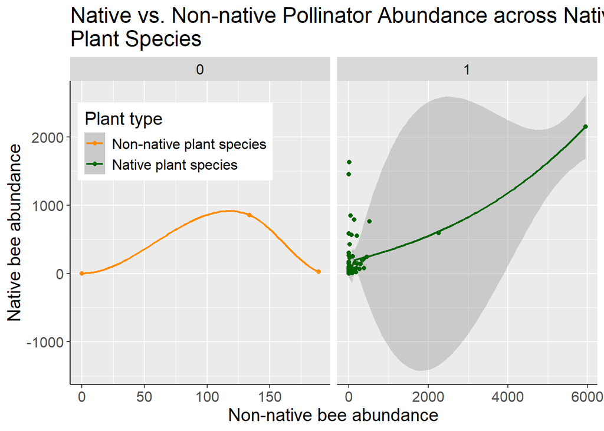

```r
#creating scatter plot to compare abundances at each species of plant

ggplot(plants, aes(x = non_nativebee_count, y = nativebee_count, color = factor(NativePlant)))+
  geom_smooth(size=0.8)+
  geom_point() +
   scale_color_manual(values = c("darkorange","darkgreen"),
                     labels = c("Non-native plant species", "Native plant species"))+
  labs( x= "Non-native bee abundance",
        y = "Native bee abundance",
        title = "Native vs. Non-native Pollinator Abundance across Native and Non-native\nPlant Species", color = "Plant type")+
  theme(axis.line = element_line(color = "black", size = 0.5))+
  theme(legend.position = c(0.2,0.8))+
  theme(text= element_text(size = 15))+
  facet_wrap(~NativePlant, scale = "free_x")
```

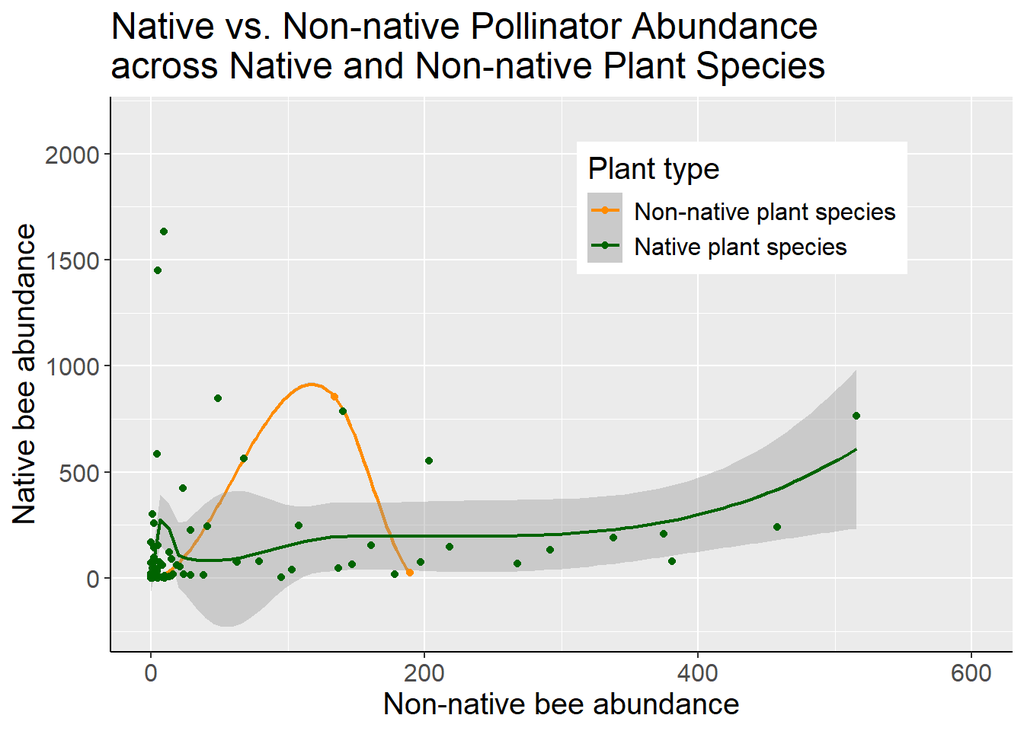

```r
#creating second zoomed in plot

ggplot(plants, aes(x = non_nativebee_count, y = nativebee_count, color = factor(NativePlant)))+
  geom_smooth(size =0.8)+
  geom_point() +
  xlim(0,600)+
   scale_color_manual(values = c("darkorange","darkgreen"),
                     labels = c("Non-native plant species", "Native plant species"))+
  labs( x= "Non-native bee abundance",
        y = "Native bee abundance",
        title = "Native vs. Non-native Pollinator Abundance\nacross Native and Non-native Plant Species", color = "Plant type")+
  theme(axis.line = element_line(color = "black", size = 0.5))+
  theme(legend.position = c(0.7,0.8))+
  theme(text= element_text(size = 15))
```

### C. Answering research question 3: How do the interactions between native bees and their preferred plants change over the growing season in high-elevation meadows?

**Analysis of native pollinator preference over time: group by type of plant visited (native or non-native); plot proportion of observations to each type per month**

```r
# Subsetting clean data reading for plotting.

phenology_plot <- clean_data %>%
  filter(NativePollinator == 1) %>%
  group_by(Month, NativePlant) %>%
  summarise(native_bee_abundance = n(), .groups = "drop") %>%
  group_by(Month)%>% #total native bee obs per month
  mutate(total_native_bees = sum(native_bee_abundance),
         proportion = native_bee_abundance / total_native_bees) %>% #creating new column 'proportion' by dividing number of native bee observations by total number of bee observations for that month then can compare each month.
  ungroup()

phenology_plot
```

```
## # A tibble: 8 × 5
##   Month NativePlant native_bee_abundance total_native_bees proportion
##   <int>       <int>                <int>             <int>      <dbl>
## 1     6           0                    7              2422    0.00289
## 2     6           1                 2415              2422    0.997
## 3     7           0                  412             10316    0.0399
## 4     7           1                 9904             10316    0.960
## 5     8           0                  461              3173    0.145
## 6     8           1                 2712              3173    0.855
## 7     9           0                    4                63    0.0635
## 8     9           1                   59                63    0.937
```

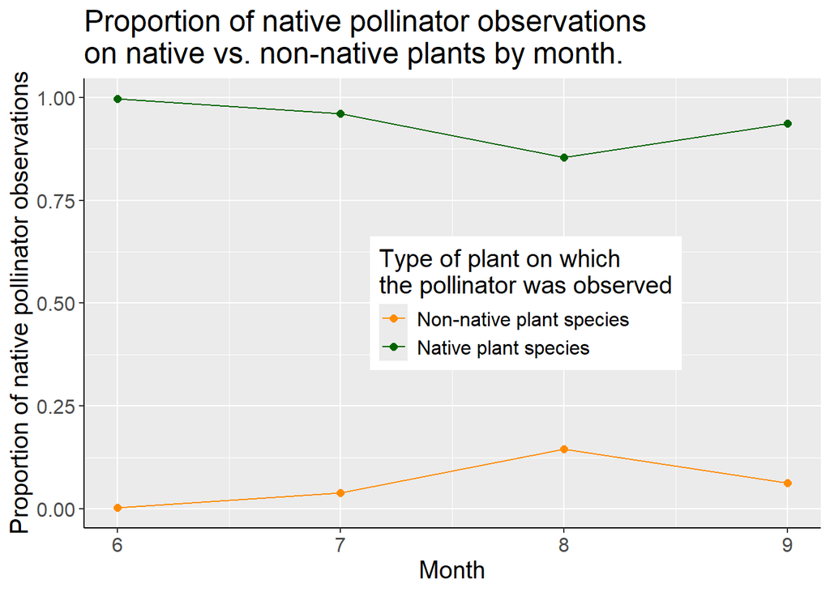

```r
## Plotting data with ggplot.

ggplot(phenology_plot, aes(x=Month, y=proportion,
                           color = factor(NativePlant), group = NativePlant))+
  geom_line(size = 0.5) +
  geom_point(size = 2) +
  scale_color_manual(values = c("darkorange","darkgreen"),
                     labels = c("Non-native plant species", "Native plant species")) +
  labs(x = "Month",
       y = "Proportion of native pollinator observations",
       color = "Type of plant on which\nthe pollinator was observed",
       title = "Proportion of native pollinator observations\non native vs. non-native plants by month.") +
  theme(axis.line = element_line(color = "black", size = 0.5))+
  theme(legend.position = c(0.6,0.5))+
  theme(text= element_text(size = 15))
```

Figure 6. Line plot showing the proportion of native pollinator observations on native vs non-native pants by month.

## 4. Conclusion:

In our results, we largely did not find what we expected to find. We expected that there would be a clear native pollinator preference for native plants, but our results suggest that the answer is more complicated. We also expected that non-native pollinator presence would negatively impact native pollinator presence, but we actually found a slight positive relationship, suggesting that competition may not be as important in the study system. Finally, we expected that there would be a shift in native pollinator preference towards non-native plants later in the season, and we found a slight increase in non-native plant interactions, but it was very weak and there was still an overwhelming proportion of interactions with native plants.

When we ran our hypothesis test for native pollinator plant preference, we found a p-value of 0.584, suggesting no significant difference in native vs. non-native plant preference among native pollinators. However, in figure 2, we can see that there are visibly many more interactions with native plants compared to non-native plants. These seemingly conflicting results may be explained by the math used to calculate the test statistic in our hypothesis test. We took the difference of two averages for our statistic, which were the averages of native pollinator interactions for a given species, for both native and non-native plant species. This may have masked a potential preference for native plant species due to the fact that only four non-native plant species were present in the data, compared to 120 native plant species. Additionally, as we can see in figure 1, only one of the non-native species, *Hypericum perforatum*, represented the majority of native-pollinator interactions at 854, while the other three non-natives represented less than 30 interactions each. This may have skewed the non-native average and subsequently the test statistic. However, we can also see in Figure 1 that only a few native plant species, such as *Gilia capitata* and *Delphinium menziezii*, represent over 1,000 native pollinator interactions each, while other native plant species represent in the hundreds or only in the tens of interactions. As such, looking at the overall preference between native vs. non-native plant preference may obscure some of the more specific preference for specific plants, some of which may be native and some of which may be non-native, like *Hypericum perforatum*. Another possible explanation for the difference between figure 2 and our hypothesis test is that there really is no significant preference for native vs. non-native plants. Figure 2 may show many more native plant interactions due to the fact that there were many more native plants and species present for native pollinators to interact with while not many non-native plants were there. In order to better understand potential reasons for these seemingly conflicting results, we could break down our interaction data by site and year and compare to plant abundance data in the same site and year to see if the presence of more or fewer non-native plant individuals impacts plant preference for native pollinators.

With respect to pollinator competition, in figures 4 and 5 we can see a slight increase in native pollinator abundance with non-native pollinator presence. This goes against our predictions, and may suggest that flora is abundant enough to meet the demands of both native and non-native pollinators in high elevation meadows. These visitation rates do not suggest that non-native bees are displacing or out competing native bees. It is important to reiterate there were only four non-native plants present in this data set, which are shown by the orange line in figures 4 and 5. Three out of these four plant species had native pollinator visitation below the smoothed green line of the native plants in figures 4 and 5, displaying a smaller range of pollinator abundances.

Our results suggest that there may not be much of an impact of non-native plants and pollinators on native plant-pollinator interactions in high-elevation meadows in Oregon. However, future research could delve deeper into the data at a finer scale to investigate more specific relationships that may be obscured by our broader approach. For example, future research could investigate differences in plant-pollinator interactions at different sites over different years, which could reveal more specific impacts of non-native species on individual sites, especially if plant abundance data from the HJ Andrews is included. Overall, our research presents a broad-level perspective on plant-pollinator interactions in a more remote study system and the potential impacts or lack of impacts of invasive species on this system.

## 5. References

Barthell, John F., John M. Randall, Robbin W. Thorp, and Adrian M. Wenner. 2001. “Promotion of Seed Set in Yellow Star-Thistle by Honey Bees: Evidence of an Invasive Mutualism.” *Ecological Applications* 11 (6): 1870–83. https://doi.org/10.1890/1051-0761(2001)011[1870:POSSIY]2.0.CO;2.

Borchardt, Kate E., Morgan Moore, Randall Cass, Matthew O’Neal, and Amy L. Toth. 2025. “Are Honey Bees Altering Wild Plant–Bee Interactions in Reconstructed Native Habitats? An Investigation of Summer Season Effects in Row-Crop Agroecosystems with Prairie Strips.” *Ecological Entomology* 50 (5): 807–23. https://doi.org/10.1111/een.13448.

Dohzono, Ikumi, Yoko Kawate Kunitake, Jun Yokoyama, and Koichi Goka. 2008. “Alien Bumble Bee Affects Native Plant Reproduction Through Interactions with Native Bumble Bees.” *Ecology* 89 (11): 3082–92. https://www.jstor.org/stable/27650864.

Dupont, Yoko, Dennis Hansen, Alfredo Valido, and Jens Olesen. 2004. “Impact of Introduced Honey Bees on Native Pollination Interactions of the Endemic Echium Wildpretii (Boraginaceae) on Tenerife, Canary Islands.” *Biological Conservation* 118 (July): 301–11. https://doi.org/10.1016/j.biocon.2003.09.010.

Morales, Carolina Laura, and Anna Traveset. 2009. “A Meta-Analysis of Impacts of Alien Vs. Native Plants on Pollinator Visitation and Reproductive Success of Co-Flowering Native Plants.” *Ecology Letters* 12 (7): 716–28. https://doi.org/10.1111/j.1461-0248.2009.01319.x.

Paini, D. R. 2004. “Impact of the Introduced Honey Bee (Apis Mellifera) (Hymenoptera: Apidae) on Native Bees: A Review.” *Austral Ecology* 29 (4): 399–407. https://doi.org/10.1111/j.1442-9993.2004.01376.x.

Spessa, Allan. 1999. “The Behavioural and Population Ecology of an Australian Native Bee, Amphylaeus Morosus Smith (Colletidae: Hylaeinae).”

Thomson, Diane. 2004. “Competitive Interactions Between the Invasive European Honey Bee and Native Bumble Bees.” *Ecology* 85 (2): 458–70. https://doi.org/10.1890/02-0626.

Traveset, A, and D Richardson. 2006. “Biological Invasions as Disruptors of Plant Reproductive Mutualisms.” *Trends in Ecology & Evolution* 21 (4): 208–16. https://doi.org/10.1016/j.tree.2006.01.006.